# Use color principles to create a spectrum

Use the principles of color matching to render an approximation to the visible spectrum on a display.

## Contents

- Load the color matching functions
- Model a display
- Compute the conversion matrix
- Compute the RGB values of spectral lights now
- There is one adjustment I would like to make to the spectral colors.
- Here is a graph of the R,G and B values for each wavelength.
- Out of gamut colors
- Convert for the nonlinear DAC values
- Show the image
- Here is a plot of the DAC values we ended up with.
- Class: Psych 221/EE 362 Tutorial: Spectrum
- Author: Wandell
- Purpose: An example calculation: making a desaturated rainbow.
- Date: 01.12.98
- Duration: 20 minutes

```matlab
ieInit
```

## Load the color matching functions

The CIE XYZ values are essential for creating calibrated signals. So, we load them first.

```matlab
wavelength = 390:730;
XYZ = ieReadSpectra('XYZEnergy.mat',wavelength);
```

## Model a display

Let's suppose the spectral power distributions of your monitor's phosphors are from the LCD-Apple.

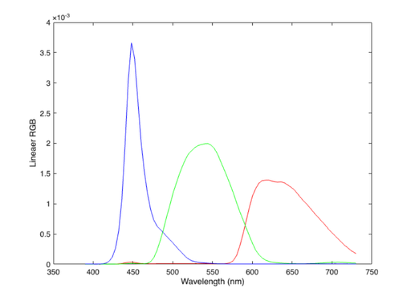

```matlab
d = displayCreate('LCD-Apple','wave',wavelength);
phosphors = displayGet(d,'spd');

% Here is a plot of the phosphors
ieNewGraphWin;
plot(wavelength,phosphors(:,1),'r', ...
    wavelength,phosphors(:,2),'g', ...
    wavelength,phosphors(:,3),'b')
xlabel('Wavelength(nm)'); ylabel('Energy (watts/st/m^2/nm');
set(gca,'xlim',[350 750]);
xlabel('Wavelength (nm)'); ylabel('Lineaer RGB');
```

## Compute the conversion matrix

This matrix converts between XYZ values and linear intensities of the monitor RGB values.

We do this in two steps. First, we find the XYZ values for each of the individual phosphors. The columns of this matrix represent the XYZ values of the red, green and blue phosphors, respectively. These values should be relatively easy to interpret.

```matlab
rgb2xyz = XYZ'*phosphors
```

```
rgb2xyz =

    0.0673    0.0622    0.0297
    0.0345    0.1287    0.0097
    0.0017    0.0146    0.1608
```

Invert the rgb2xyz matrix so that we can compute from XYZ back to linear RGB values

```matlab
xyz2rgb = inv(rgb2xyz)
```

```
xyz2rgb =

   19.6282   -9.1298   -3.0667
   -5.2759   10.2748    0.3502
    0.2671   -0.8321    6.2202
```

Notice that the values of the xyz2rgb matrix contain negative values and are difficult to interpret directly. Such is life.

## Compute the RGB values of spectral lights now

Remember that the XYZ values of each spectral light is contained in the rows of the XYZ matrix. So, we need only to multiply the two matrices as in:

```matlab
rgbSpectrum = xyz2rgb*XYZ'; %#ok<MINV>
```

This calculation would produce the rgbSpectrum for monochrome lights of equal energy. But, equal energy monochrome lights do not appear equally bright. The brightest part of the spectrum is near 550nm, and the blue and red ends are much dimmer (per unit watt).

## There is one adjustment I would like to make to the spectral colors.

I would like to display spectral colors that are imilar in their brightness. To adjust the overall luminance of the spectral values, I will scale the XYZ values of each spectral light by a function that is related to the Y value. Remember that the Y value is correlated with brightness. So, if we scale by the Y value, we can compensate a bit for brightness differences.

Here is what I propose to use as a scale factor.

```matlab
Yvalue = XYZ(:,2);
scaleFactor = (Yvalue + 0.4);
```

Now, let's scale the rgb values. Pay attention to the fact that I am doing this scaling in the linear RGB space. This calculation would be wrong if I did it on the frame buffer values, rather than the linear RGB intensities.

```matlab
rgbSpectrum = rgbSpectrum*diag( 1 ./ scaleFactor);
rgbSpectrum = rgbSpectrum';
```

Here is a plot of the scale factors I used to make the brightness of the wavelengths more nearly equal.

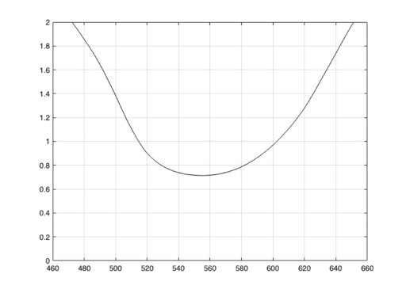

```matlab
ieNewGraphWin;
plot(wavelength,1./scaleFactor,'k')
set(gca,'ylim',[0 2]), grid on
```

## Here is a graph of the R,G and B values for each wavelength.

The horizontal axis shows wavelength and the three colored curves show the linear intensity values needed for the phoshors.

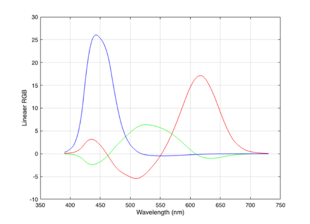

```matlab
ieNewGraphWin;
plot(wavelength,rgbSpectrum(:,1),'r', ...
    wavelength,rgbSpectrum(:,2),'g', ...
    wavelength,rgbSpectrum(:,3),'b')
grid on
set(gca,'xlim',[350 750]);
xlabel('Wavelength (nm)'); ylabel('Lineaer RGB');
```

## Out of gamut colors

Some of the RGB values are negative. These are called "out of gamut" and cannot be displayed precisely. There is no getting around this problem either for this example or in many real world applications. Some physical colors in the world simply cannot be displayed on conventional monitors, with three primaries. This corresponds to the observation that in the color-matching experiment sometimes we must move one of the primaries to the other side of the field.

There are many different suggestions (hacks) that people use to overcome the basic physical limitation of displays. For our purposes, we can use a fairly simple compromise -- some of you may like it, others may not. That is the nature of this business.

We can display these rgb values superimposed on a constant gray background. By superimposing the spectrum on a constant background, we can both add and subtract RGB values.

I propose that we use a gray background that is only as bright as the most negative rgbSpectrum value.

```matlab
grayLevel = abs(min(rgbSpectrum(:)))
rgbSpectrum = (rgbSpectrum + grayLevel);
```

```
grayLevel =

    5.4240
```

And, we scale the RGB values in rgbSpectrum so they are as large as possible, but the sum of the background and these values will still be less than the maximum display value (1).

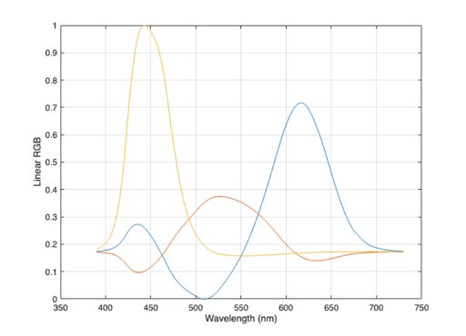

```matlab
rgbSpectrum = rgbSpectrum/max(rgbSpectrum(:));

ieNewGraphWin;
plot(wavelength,rgbSpectrum), grid on
set(gca,'xlim',[350 750]);
xlabel('Wavelength (nm)'); ylabel('Linear RGB');
```

```matlab
% load cMatch/hit489Gam
```

## Convert for the nonlinear DAC values

Here is the function we use to convert the linear values in rgb to the frame buffer (DAC) values.

```matlab
gTable = displayGet(d,'gtable');
DAC = lrgb2srgb(rgbSpectrum);
```

To display the image, we sample every other wavelength value. I am worried about running out of color map entries!

```matlab
waveSamp = 1:2:size(DAC,1);
mp = DAC(waveSamp,:);
wavelength = wavelength(waveSamp);
```

## Show the image

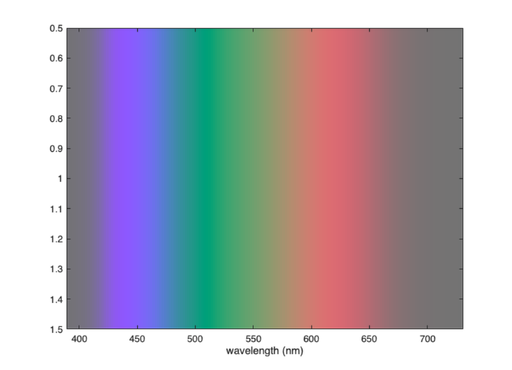

```matlab
% Create a linear ramp to show the color map values.
im = 1:size(mp,1);

% and show 'em
ieNewGraphWin;
mp = mp/max(mp(:));
colormap(mp);
image(wavelength,1,im)
xlabel('wavelength (nm)')
```

Notice that the color start to fade towards the end. Why do you think that is? Try varying some of the choices I made, such as the scaleFactor and the intensity of the gray background.

## Here is a plot of the DAC values we ended up with.

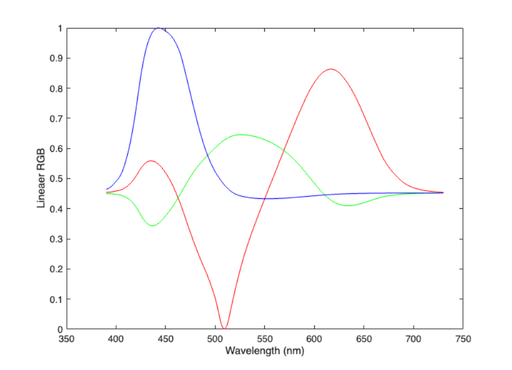

```matlab
ieNewGraphWin;
plot(wavelength, DAC(waveSamp,1),'-r',...
    wavelength, DAC(waveSamp,2),'-g',...
    wavelength,DAC(waveSamp,3),'-b')
set(gca,'xlim',[350 750]);
xlabel('Wavelength (nm)'); ylabel('Lineaer RGB');
```

Notice that the overall saturation is quite limited by one part of the spectrum. Perhaps if we didn't try to reproduce just that part of the image, or we adjusted just that part, we could obtain a more saturated overall appearance. Again, a design decision.

[Published with MATLAB® R2025b](https://www.mathworks.com/products/matlab/)